# CS Structure in Single-Gene Regions (LDL)

Xinhe Sun

2026-06-26

## Overview

For regions reporting exactly one gene (combined_pip > 0.8), we examine the credible set (CS) structure to understand the number and nature of independent signals supporting that gene.

- **Case 1**: Multiple CS, all supporting the same gene only. No SNP-only or other-gene CS present.
- **Case 2**: Multiple CS, one or more CS support the gene, others are variants (SNP-only). No other-gene CS.
- **Case 3**: Multiple CS, one or more CS support the gene, one or more CS support other genes (with combined PIP < 0.8), and possibly SNP-only CS.
- **Case 4**: No CS. Genes achieve high combined PIP by accumulating small contributions across multiple sets without entering any single credible set.
- **Case 5**: Single CS.

## Load data and combine gene PIPs

```r
trait <- "LDL-ukb-d-30780_irnt"
folder_results <- "snakemake_outputs/"

mapping_predictdb <- readRDS("/project2/xinhe/shared_data/multigroup_ctwas/weights/mapping_files/PredictDB_mapping.RDS")
mapping_munro <- readRDS("/project2/xinhe/shared_data/multigroup_ctwas/weights/mapping_files/Munro_mapping.RDS")
mapping_ed <- readRDS("/project2/xinhe/shared_data/multigroup_ctwas/weights/mapping_files/mapping_edqtl.RDS")
mapping_all <- rbind(mapping_predictdb, mapping_munro, mapping_ed)
mapping_dt <- as.data.table(mapping_all)

finemap_res <- readRDS(paste0(folder_results, trait, "/", trait, ".3qtls.thin1.shared_all.L5.regionmerge_with_mappingtable_finemap_res.RDS"))
susie_alpha_res <- readRDS(paste0(folder_results, trait, "/", trait, ".3qtls.thin1.shared_all.L5.regionmerge_with_mappingtable_susie_alpha_res.RDS"))
```

```r
ctwas_gene_anno <- anno_susie_alpha_res(
  susie_alpha_res,
  mapping_table = mapping_all,
  map_by = "molecular_id",
  drop_unmapped = TRUE
)
```

```
## 2026-06-26 15:21:43 INFO::Annotating susie alpha result...
## 2026-06-26 15:21:45 INFO::Map molecular traits to genes.
## 2026-06-26 15:21:48 INFO::Split PIPs for molecular traits mapped to multiple genes
```

```r
gene_pip_df <- combine_gene_pips(
  ctwas_gene_anno,
  group_by = "gene_name",
  by = "type",
  method = "combine_cs",
  filter_cs = FALSE,
  include_cs_id = TRUE,
  include_set_id = TRUE
)
```

```
## 2026-06-26 15:22:07 INFO::Compute combined PIPs...
```

```r
set_ids <- gene_pip_df$combined_set_id
first_set <- sub(",.*$", "", set_ids)
gene_pip_df$region_id <- sub("\\.L[0-9]+$", "", first_set)
```

## Identify single-gene regions

```r
sig_genes <- gene_pip_df[gene_pip_df$combined_pip > 0.8, ]
sig_dt <- as.data.table(sig_genes)
genes_per_region <- sig_dt[, .(n_genes = uniqueN(gene_name)), by = region_id]

cat("Total genes with combined_pip > 0.8:", nrow(sig_genes), "\n")
```

```
## Total genes with combined_pip > 0.8: 73
```

```r
cat("Total regions with significant genes:", nrow(genes_per_region), "\n")
```

```
## Total regions with significant genes: 72
```

```r
knitr::kable(as.data.frame(table(genes_per_region$n_genes)),
             col.names = c("Genes per region", "Number of regions"),
             caption = "Distribution of significant genes per region")
```

Distribution of significant genes per region

| Genes per region | Number of regions |
| --- | --- |
| 1 | 71 |
| 2 | 1 |

```r
single_gene_regions <- genes_per_region[n_genes == 1]
cat("Single-gene regions:", nrow(single_gene_regions), "\n")
```

```
## Single-gene regions: 71
```

## Analyze CS structure in single-gene regions

```r
finemap_dt <- as.data.table(finemap_res)

results <- list()

for (i in seq_len(nrow(single_gene_regions))) {
  rid <- single_gene_regions$region_id[i]
  gene_name_val <- sig_dt[region_id == rid, unique(gene_name)]

  region_fm <- finemap_dt[region_id == rid]
  region_cs <- region_fm[!is.na(cs)]

  if (nrow(region_cs) == 0) {
    results[[i]] <- list(
      region_id = rid, gene_name = gene_name_val,
      n_cs = 0L, n_cs_mol = 0L, n_cs_snp = 0L,
      n_cs_sig = 0L, n_cs_other_gene = 0L,
      max_mol_pip = NA_real_, all_mol_below_08 = NA,
      case = "case4_no_cs", cs_details = ""
    )
    next
  }

  ucs <- unique(region_cs$cs)
  n_cs <- length(ucs)

  # Classify each CS: SNP-only, mol for sig gene, or mol for other gene
  cs_type <- sapply(ucs, function(cv) {
    ents <- region_cs[cs == cv]
    mol <- ents[type != "SNP"]
    if (nrow(mol) == 0) return("snp_only")
    mol_ids <- unique(mol$molecular_id)
    mapped_genes <- unique(mapping_dt[molecular_id %in% mol_ids, gene_name])
    if (gene_name_val %in% mapped_genes) return("sig_gene")
    return("other_gene")
  })

  n_cs_snp <- sum(cs_type == "snp_only")
  n_cs_sig <- sum(cs_type == "sig_gene")
  n_cs_other_gene <- sum(cs_type == "other_gene")
  n_cs_mol <- n_cs_sig + n_cs_other_gene

  details <- sapply(ucs, function(cv) {
    ents <- region_cs[cs == cv]
    mol <- ents[type != "SNP"]
    if (nrow(mol) > 0) {
      types_found <- unique(mol$type)
      contexts_found <- unique(mol$context)
      mol_ids <- unique(mol$molecular_id)
      mapped_genes <- unique(mapping_dt[molecular_id %in% mol_ids, gene_name])
      gene_str <- paste(mapped_genes, collapse = ", ")
      paste0(cv, ": ", paste(types_found, collapse = "/"),
             " (", paste(contexts_found, collapse = ", "),
             ") [genes: ", gene_str, "]")
    } else {
      paste0(cv, ": SNP-only (n=", nrow(ents), ")")
    }
  })

  # Max mol PIP for traits mapping to sig gene only
  mol_entries_sig <- region_cs[type != "SNP"]
  if (nrow(mol_entries_sig) > 0) {
    sig_mol_ids <- mapping_dt[gene_name == gene_name_val, unique(molecular_id)]
    mol_for_sig <- mol_entries_sig[molecular_id %in% sig_mol_ids]
    if (nrow(mol_for_sig) > 0) {
      max_mol_pip <- max(mol_for_sig$susie_pip)
      all_mol_below_08 <- all(mol_for_sig$susie_pip < 0.8)
    } else {
      max_mol_pip <- NA_real_
      all_mol_below_08 <- NA
    }
  } else {
    max_mol_pip <- NA_real_
    all_mol_below_08 <- NA
  }

  if (n_cs == 1) {
    cl <- "case5_single_cs"
  } else if (n_cs_sig >= 1 & n_cs_other_gene > 0) {
    cl <- "case3_sig_gene_plus_other_genes"
  } else if (n_cs_sig >= 1 & n_cs_other_gene == 0 & n_cs_snp >= 1) {
    cl <- "case2_one_cs_gene_rest_snp"
  } else if (n_cs_sig > 1 & n_cs_other_gene == 0 & n_cs_snp == 0) {
    cl <- "case1_multi_cs_same_gene"
  } else if (n_cs_sig == 0) {
    cl <- "case4_no_cs"
  } else {
    cl <- "other"
  }

  results[[i]] <- list(
    region_id = rid, gene_name = gene_name_val,
    n_cs = n_cs, n_cs_mol = n_cs_mol, n_cs_snp = n_cs_snp,
    n_cs_sig = n_cs_sig, n_cs_other_gene = n_cs_other_gene,
    max_mol_pip = max_mol_pip, all_mol_below_08 = all_mol_below_08,
    case = cl, cs_details = paste(details, collapse = " | ")
  )
}

results_df <- rbindlist(results)
```

## Summary

```r
case_labels <- c(
  "case1_multi_cs_same_gene" = "Case 1: Multiple CS, supporting same gene",
  "case2_one_cs_gene_rest_snp" = "Case 2: Multiple CS, gene + variants",
  "case3_sig_gene_plus_other_genes" = "Case 3: Multiple CS, gene + other genes (+variants)",
  "case4_no_cs" = "Case 4: No CS",
  "case5_single_cs" = "Case 5: Single CS"
)

case_order <- c("case1_multi_cs_same_gene", "case2_one_cs_gene_rest_snp",
                "case3_sig_gene_plus_other_genes", "case4_no_cs", "case5_single_cs")

case_counts <- as.data.frame(table(factor(results_df$case, levels = case_order)))
colnames(case_counts) <- c("Case", "Count")
case_counts$Description <- case_labels[as.character(case_counts$Case)]
case_counts <- case_counts[, c("Case", "Description", "Count")]

knitr::kable(case_counts, row.names = FALSE,
             caption = "Breakdown of CS structure in single-gene regions")
```

Breakdown of CS structure in single-gene regions

| Case | Description | Count |
| --- | --- | --- |
| case1_multi_cs_same_gene | Case 1: Multiple CS, supporting same gene | 4 |
| case2_one_cs_gene_rest_snp | Case 2: Multiple CS, gene + variants | 11 |
| case3_sig_gene_plus_other_genes | Case 3: Multiple CS, gene + other genes (+variants) | 6 |
| case4_no_cs | Case 4: No CS | 9 |
| case5_single_cs | Case 5: Single CS | 41 |

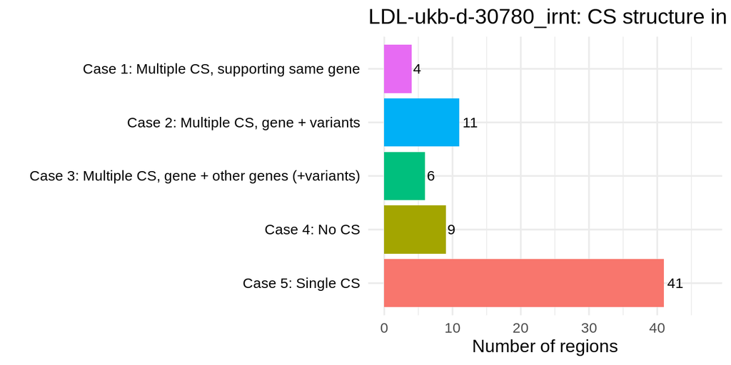

```r
plot_df <- results_df[, .(count = .N), by = case]
plot_df[, label := case_labels[case]]
label_order <- case_labels[case_order]
plot_df[, label := factor(label, levels = rev(label_order))]

ggplot(plot_df, aes(x = label, y = count, fill = label)) +
  geom_col(show.legend = FALSE) +
  geom_text(aes(label = count), hjust = -0.2, size = 4) +
  coord_flip() +
  labs(x = "", y = "Number of regions", title = paste0(trait, ": CS structure in single-gene regions")) +
  theme_minimal(base_size = 14) +
  theme(axis.text.y = element_text(color = "black")) +
  ylim(0, max(plot_df$count) * 1.15)
```

## Case 1: Multiple CS, all supporting the same gene only

These regions have multiple CS, and all CS support molecular traits mapping to the same significant gene (e.g., eQTL in one tissue/CS, sQTL in another CS). No SNP-only or other-gene CS present.

```r
c1 <- results_df[case == "case1_multi_cs_same_gene",
                 .(Gene = gene_name, Region = region_id,
                   `Total CS` = n_cs, `CS Sig Gene` = n_cs_sig,
                   `CS Other Gene` = n_cs_other_gene, `CS SNP` = n_cs_snp,
                   `Max Mol PIP` = max_mol_pip, `All Mol PIP < 0.8` = all_mol_below_08,
                   `CS Details` = cs_details)]
DT::datatable(c1, options = list(pageLength = 20, scrollX = TRUE),
              caption = "Case 1: Multiple CS supporting the same gene")
```

|  | Gene | Region | Total CS | CS Sig Gene | CS Other Gene | CS SNP | Max Mol PIP | All Mol PIP < 0.8 | CS Details |
| --- | --- | --- | --- | --- | --- | --- | --- | --- | --- |
| 1 | HPR | 16_71020125_72901251 | 2 | 2 | 0 | 0 | 0.9999735788472783 | False | L2: eQTL (Liver) [genes: HPR] \| L1: sQTL (Whole_Blood, Adipose_Visceral_Omentum, Liver) [genes: HP, HPR] |
| 2 | TRIM39 | 6_29770194_30830391 | 2 | 2 | 0 | 0 | 0.9897906408571608 | False | L1: eQTL (Liver) [genes: TRIM39] \| L2: sQTL (Artery_Aorta, Artery_Tibial, Spleen) [genes: TRIM39] |
| 3 | DNAJC13 | 3_132117672_133533329 | 2 | 2 | 0 | 0 | 0.8280608631432697 | False | L1: eQTL (Artery_Aorta, Spleen) [genes: DNAJC13] \| L2: eQTL/sQTL (Adipose_Visceral_Omentum, Liver, Artery_Aorta, Artery_Tibial, Spleen, Muscle_Skeletal, Skin_Not_Sun_Exposed_Suprapubic) [genes: DNAJC… |
| 4 | SNX17 | 2_26672117_28375910 | 2 | 2 | 0 | 0 | 0.6525443730058634 | True | L2: eQTL/sQTL (Artery_Aorta, Whole_Blood, Adipose_Visceral_Omentum, Artery_Tibial, Spleen, Muscle_Skeletal, Liver, Skin_Not_Sun_Exposed_Suprapubic) [genes: EIF2B4, SNX17, ZNF513, PPM1G, FNDC4, GCKR, G… |

### Case 1 sub-classification: individual PIP check

For Case 1 genes, we check whether all individual molecular trait PIPs (susie_pip) are below 0.8 before combining. Genes where all individual PIPs < 0.8 are truly “multi-signal” — they only reach significance by combining evidence across multiple independent credible sets. Genes where at least one molecular trait already has PIP >= 0.8 would have been identified even without combining.

```r
c1_res <- results_df[case == "case1_multi_cs_same_gene"]

cat("Case 1 genes where ALL individual molecular PIPs < 0.8:", sum(c1_res$all_mol_below_08, na.rm = TRUE), "\n")
```

```
## Case 1 genes where ALL individual molecular PIPs < 0.8: 1
```

```r
cat("Case 1 genes where some individual molecular PIP >= 0.8:", sum(!c1_res$all_mol_below_08, na.rm = TRUE), "\n")
```

```
## Case 1 genes where some individual molecular PIP >= 0.8: 3
```

#### Case 1a: All individual molecular PIPs < 0.8 (truly multi-signal)

These genes only reach combined_pip > 0.8 by aggregating evidence across multiple CS — no single molecular trait is individually significant.

```r
c1a <- results_df[case == "case1_multi_cs_same_gene" & all_mol_below_08 == TRUE,
                  .(Gene = gene_name, Region = region_id,
                    `Total CS` = n_cs, `Mol CS` = n_cs_mol,
                    `Max Mol PIP` = round(max_mol_pip, 4),
                    `CS Details` = cs_details)]

c1a <- merge(c1a, sig_dt[, .(gene_name, combined_pip)],
             by.x = "Gene", by.y = "gene_name", all.x = TRUE)
setnames(c1a, "combined_pip", "Combined PIP")
c1a[, `Combined PIP` := round(`Combined PIP`, 4)]

DT::datatable(c1a, options = list(pageLength = 20, scrollX = TRUE),
              caption = "Case 1a: All individual molecular PIPs < 0.8")
```

|  | Gene | Region | Total CS | Mol CS | Max Mol PIP | CS Details | Combined PIP |
| --- | --- | --- | --- | --- | --- | --- | --- |
| 1 | SNX17 | 2_26672117_28375910 | 2 | 2 | 0.6525 | L2: eQTL/sQTL (Artery_Aorta, Whole_Blood, Adipose_Visceral_Omentum, Artery_Tibial, Spleen, Muscle_Skeletal, Liver, Skin_Not_Sun_Exposed_Suprapubic) [genes: EIF2B4, SNX17, ZNF513, PPM1G, FNDC4, GCKR, G… | 0.9119 |

#### Case 1b: At least one individual molecular PIP >= 0.8

These genes already have at least one molecular trait with high individual PIP — the multi-CS structure provides additional support but is not required for identification.

```r
c1b <- results_df[case == "case1_multi_cs_same_gene" & all_mol_below_08 == FALSE,
                  .(Gene = gene_name, Region = region_id,
                    `Total CS` = n_cs, `Mol CS` = n_cs_mol,
                    `Max Mol PIP` = round(max_mol_pip, 4),
                    `CS Details` = cs_details)]

c1b <- merge(c1b, sig_dt[, .(gene_name, combined_pip)],
             by.x = "Gene", by.y = "gene_name", all.x = TRUE)
setnames(c1b, "combined_pip", "Combined PIP")
c1b[, `Combined PIP` := round(`Combined PIP`, 4)]

DT::datatable(c1b, options = list(pageLength = 20, scrollX = TRUE),
              caption = "Case 1b: At least one molecular PIP >= 0.8")
```

|  | Gene | Region | Total CS | Mol CS | Max Mol PIP | CS Details | Combined PIP |
| --- | --- | --- | --- | --- | --- | --- | --- |
| 1 | DNAJC13 | 3_132117672_133533329 | 2 | 2 | 0.8281 | L1: eQTL (Artery_Aorta, Spleen) [genes: DNAJC13] \| L2: eQTL/sQTL (Adipose_Visceral_Omentum, Liver, Artery_Aorta, Artery_Tibial, Spleen, Muscle_Skeletal, Skin_Not_Sun_Exposed_Suprapubic) [genes: DNAJC… | 0.9837 |
| 2 | HPR | 16_71020125_72901251 | 2 | 2 | 1 | L2: eQTL (Liver) [genes: HPR] \| L1: sQTL (Whole_Blood, Adipose_Visceral_Omentum, Liver) [genes: HP, HPR] | 1 |
| 3 | TRIM39 | 6_29770194_30830391 | 2 | 2 | 0.9898 | L1: eQTL (Liver) [genes: TRIM39] \| L2: sQTL (Artery_Aorta, Artery_Tibial, Spleen) [genes: TRIM39] | 0.9938 |

### Case 1 details

```r
c1_df <- results_df[case == "case1_multi_cs_same_gene"]

for (j in seq_len(nrow(c1_df))) {
  rid <- c1_df$region_id[j]
  gn <- c1_df$gene_name[j]

  cat(sprintf("\n#### %s (region: %s)\n\n", gn, rid))

  region_fm <- finemap_dt[region_id == rid & !is.na(cs)]
  mol_entries <- region_fm[type != "SNP", .(id, type, context, group, cs, susie_pip, z)]
  mol_entries <- mol_entries[order(cs, -susie_pip)]

  if (nrow(mol_entries) > 0) {
    print(knitr::kable(mol_entries, digits = 4,
                       caption = paste0("Molecular traits in CS for ", gn)))
    cat("\n")
  }
}
```

#### HPR (region: 16_71020125_72901251)

Molecular traits in CS for HPR

| id | type | context | group | cs | susie_pip | z |
| --- | --- | --- | --- | --- | --- | --- |
| intron_16_72058355_72059114\|Whole_Blood_sQTL | sQTL | Whole_Blood | Whole_Blood\|sQTL | L1 | 0.4858 | 21.9140 |
| intron_16_72057466_72058254\|Liver_sQTL | sQTL | Liver | Liver\|sQTL | L1 | 0.2943 | 21.8686 |
| intron_16_72074385_72075145\|Adipose_Visceral_Omentum_sQTL | sQTL | Adipose_Visceral_Omentum | Adipose_Visceral_Omentum\|sQTL | L1 | 0.1853 | -22.0706 |
| ENSG00000261701.6\|Liver_eQTL | eQTL | Liver | Liver\|eQTL | L2 | 1.0000 | -17.9628 |

#### TRIM39 (region: 6_29770194_30830391)

Molecular traits in CS for TRIM39

| id | type | context | group | cs | susie_pip | z |
| --- | --- | --- | --- | --- | --- | --- |
| ENSG00000204599.14\|Liver_eQTL | eQTL | Liver | Liver\|eQTL | L1 | 0.9898 | 8.8402 |
| intron_6_30335975_30339908\|Artery_Aorta_sQTL | sQTL | Artery_Aorta | Artery_Aorta\|sQTL | L2 | 0.0253 | 5.8175 |
| intron_6_30335975_30339908\|Artery_Tibial_sQTL | sQTL | Artery_Tibial | Artery_Tibial\|sQTL | L2 | 0.0073 | 5.8175 |
| intron_6_30335975_30339908\|Spleen_sQTL | sQTL | Spleen | Spleen\|sQTL | L2 | 0.0049 | 5.8175 |

#### DNAJC13 (region: 3_132117672_133533329)

Molecular traits in CS for DNAJC13

| id | type | context | group | cs | susie_pip | z |
| --- | --- | --- | --- | --- | --- | --- |
| ENSG00000138246.15\|Spleen_eQTL | eQTL | Spleen | Spleen\|eQTL | L1 | 0.8281 | -7.0358 |
| ENSG00000138246.15\|Artery_Aorta_eQTL | eQTL | Artery_Aorta | Artery_Aorta\|eQTL | L1 | 0.1419 | -6.8680 |
| intron_3_132607025_132618634\|Artery_Aorta_sQTL | sQTL | Artery_Aorta | Artery_Aorta\|sQTL | L2 | 0.1415 | 5.4822 |
| intron_3_132467313_132472557\|Artery_Aorta_sQTL | sQTL | Artery_Aorta | Artery_Aorta\|sQTL | L2 | 0.0950 | -5.2863 |
| intron_3_132467313_132473145\|Artery_Aorta_sQTL | sQTL | Artery_Aorta | Artery_Aorta\|sQTL | L2 | 0.0950 | 5.2863 |
| ENSG00000138246.15\|Liver_eQTL | eQTL | Liver | Liver\|eQTL | L2 | 0.0700 | 4.8455 |
| intron_3_132467313_132472557\|Muscle_Skeletal_sQTL | sQTL | Muscle_Skeletal | Muscle_Skeletal\|sQTL | L2 | 0.0471 | -5.2863 |
| intron_3_132467313_132473145\|Muscle_Skeletal_sQTL | sQTL | Muscle_Skeletal | Muscle_Skeletal\|sQTL | L2 | 0.0471 | 5.2863 |
| intron_3_132467313_132473145\|Adipose_Visceral_Omentum_sQTL | sQTL | Adipose_Visceral_Omentum | Adipose_Visceral_Omentum\|sQTL | L2 | 0.0412 | 5.2863 |
| intron_3_132467313_132472557\|Artery_Tibial_sQTL | sQTL | Artery_Tibial | Artery_Tibial\|sQTL | L2 | 0.0274 | -5.2863 |
| intron_3_132467313_132473145\|Artery_Tibial_sQTL | sQTL | Artery_Tibial | Artery_Tibial\|sQTL | L2 | 0.0274 | 5.2863 |
| intron_3_132694965_132696731\|Liver_sQTL | sQTL | Liver | Liver\|sQTL | L2 | 0.0113 | 4.9786 |
| intron_3_132696813_132697260\|Liver_sQTL | sQTL | Liver | Liver\|sQTL | L2 | 0.0113 | 4.9786 |
| intron_3_132696813_132697260\|Artery_Aorta_sQTL | sQTL | Artery_Aorta | Artery_Aorta\|sQTL | L2 | 0.0082 | 4.9786 |
| intron_3_132696813_132697260\|Skin_Not_Sun_Exposed_Suprapubic_sQTL | sQTL | Skin_Not_Sun_Exposed_Suprapubic | Skin_Not_Sun_Exposed_Suprapubic\|sQTL | L2 | 0.0066 | 4.9786 |
| intron_3_132607025_132618634\|Skin_Not_Sun_Exposed_Suprapubic_sQTL | sQTL | Skin_Not_Sun_Exposed_Suprapubic | Skin_Not_Sun_Exposed_Suprapubic\|sQTL | L2 | 0.0057 | 4.7398 |
| intron_3_132696813_132697260\|Muscle_Skeletal_sQTL | sQTL | Muscle_Skeletal | Muscle_Skeletal\|sQTL | L2 | 0.0041 | 4.9786 |
| intron_3_132696813_132697260\|Adipose_Visceral_Omentum_sQTL | sQTL | Adipose_Visceral_Omentum | Adipose_Visceral_Omentum\|sQTL | L2 | 0.0036 | 4.9786 |
| intron_3_132694965_132697260\|Adipose_Visceral_Omentum_sQTL | sQTL | Adipose_Visceral_Omentum | Adipose_Visceral_Omentum\|sQTL | L2 | 0.0036 | -4.9786 |
| ENSG00000081307.12\|Adipose_Visceral_Omentum_eQTL | eQTL | Adipose_Visceral_Omentum | Adipose_Visceral_Omentum\|eQTL | L2 | 0.0027 | -4.8197 |
| intron_3_132696813_132697260\|Artery_Tibial_sQTL | sQTL | Artery_Tibial | Artery_Tibial\|sQTL | L2 | 0.0024 | 4.9786 |
| intron_3_132696813_132697260\|Spleen_sQTL | sQTL | Spleen | Spleen\|sQTL | L2 | 0.0016 | 4.9786 |

#### SNX17 (region: 2_26672117_28375910)

Molecular traits in CS for SNX17

| id | type | context | group | cs | susie_pip | z |
| --- | --- | --- | --- | --- | --- | --- |
| intron_2_27372740_27373247\|Skin_Not_Sun_Exposed_Suprapubic_sQTL | sQTL | Skin_Not_Sun_Exposed_Suprapubic | Skin_Not_Sun_Exposed_Suprapubic\|sQTL | L1 | 0.6525 | 14.3962 |
| intron_2_27372740_27373247\|Artery_Tibial_sQTL | sQTL | Artery_Tibial | Artery_Tibial\|sQTL | L1 | 0.2361 | 14.3962 |
| ENSG00000163795.13\|Artery_Aorta_eQTL | eQTL | Artery_Aorta | Artery_Aorta\|eQTL | L2 | 0.1366 | 4.1914 |
| ENSG00000163795.13\|Whole_Blood_eQTL | eQTL | Whole_Blood | Whole_Blood\|eQTL | L2 | 0.0772 | 3.5401 |
| ENSG00000163795.13\|Artery_Tibial_eQTL | eQTL | Artery_Tibial | Artery_Tibial\|eQTL | L2 | 0.0680 | 4.1491 |
| ENSG00000115241.10\|Spleen_eQTL | eQTL | Spleen | Spleen\|eQTL | L2 | 0.0522 | 5.7306 |
| ENSG00000115234.10\|Whole_Blood_eQTL | eQTL | Whole_Blood | Whole_Blood\|eQTL | L2 | 0.0376 | 5.7531 |
| intron_2_27428731_27433254\|Whole_Blood_sQTL | sQTL | Whole_Blood | Whole_Blood\|sQTL | L2 | 0.0361 | 5.5550 |
| intron_2_27428731_27433249\|Whole_Blood_sQTL | sQTL | Whole_Blood | Whole_Blood\|sQTL | L2 | 0.0361 | -5.5550 |
| intron_2_27376216_27376313\|Artery_Aorta_sQTL | sQTL | Artery_Aorta | Artery_Aorta\|sQTL | L2 | 0.0245 | -5.8048 |
| intron_2_27376183_27376313\|Artery_Aorta_sQTL | sQTL | Artery_Aorta | Artery_Aorta\|sQTL | L2 | 0.0245 | 5.8048 |
| intron_2_27435227_27436753\|Liver_sQTL | sQTL | Liver | Liver\|sQTL | L2 | 0.0222 | -5.6991 |
| intron_2_27376216_27376313\|Skin_Not_Sun_Exposed_Suprapubic_sQTL | sQTL | Skin_Not_Sun_Exposed_Suprapubic | Skin_Not_Sun_Exposed_Suprapubic\|sQTL | L2 | 0.0195 | -5.8048 |
| intron_2_27376183_27376313\|Skin_Not_Sun_Exposed_Suprapubic_sQTL | sQTL | Skin_Not_Sun_Exposed_Suprapubic | Skin_Not_Sun_Exposed_Suprapubic\|sQTL | L2 | 0.0195 | 5.8048 |
| ENSG00000115234.10\|Artery_Aorta_eQTL | eQTL | Artery_Aorta | Artery_Aorta\|eQTL | L2 | 0.0193 | 5.7531 |
| ENSG00000115241.10\|Muscle_Skeletal_eQTL | eQTL | Muscle_Skeletal | Muscle_Skeletal\|eQTL | L2 | 0.0192 | 5.7306 |
| intron_2_27368113_27368372\|Whole_Blood_sQTL | sQTL | Whole_Blood | Whole_Blood\|sQTL | L2 | 0.0159 | 5.7531 |
| intron_2_27369549_27369876\|Liver_sQTL | sQTL | Liver | Liver\|sQTL | L2 | 0.0147 | -5.7531 |
| intron_2_27498797_27499142\|Liver_sQTL | sQTL | Liver | Liver\|sQTL | L2 | 0.0138 | 5.7470 |
| intron_2_27499450_27501135\|Liver_sQTL | sQTL | Liver | Liver\|sQTL | L2 | 0.0138 | 5.7470 |
| intron_2_27498797_27499397\|Liver_sQTL | sQTL | Liver | Liver\|sQTL | L2 | 0.0138 | -5.7470 |
| ENSG00000115241.10\|Adipose_Visceral_Omentum_eQTL | eQTL | Adipose_Visceral_Omentum | Adipose_Visceral_Omentum\|eQTL | L2 | 0.0126 | 5.7306 |
| intron_2_27465882_27470928\|Artery_Aorta_sQTL | sQTL | Artery_Aorta | Artery_Aorta\|sQTL | L2 | 0.0123 | -5.7374 |
| intron_2_27376183_27376313\|Muscle_Skeletal_sQTL | sQTL | Muscle_Skeletal | Muscle_Skeletal\|sQTL | L2 | 0.0121 | 5.8048 |
| intron_2_27369549_27369876\|Artery_Aorta_sQTL | sQTL | Artery_Aorta | Artery_Aorta\|sQTL | L2 | 0.0107 | -5.7531 |
| intron_2_27369545_27369876\|Artery_Aorta_sQTL | sQTL | Artery_Aorta | Artery_Aorta\|sQTL | L2 | 0.0107 | 5.7531 |
| intron_2_27376183_27376313\|Adipose_Visceral_Omentum_sQTL | sQTL | Adipose_Visceral_Omentum | Adipose_Visceral_Omentum\|sQTL | L2 | 0.0106 | 5.8048 |
| intron_2_27376216_27376313\|Adipose_Visceral_Omentum_sQTL | sQTL | Adipose_Visceral_Omentum | Adipose_Visceral_Omentum\|sQTL | L2 | 0.0106 | -5.8048 |
| ENSG00000115211.15\|Artery_Tibial_eQTL | eQTL | Artery_Tibial | Artery_Tibial\|eQTL | L2 | 0.0102 | -5.7531 |
| ENSG00000115234.10\|Artery_Tibial_eQTL | eQTL | Artery_Tibial | Artery_Tibial\|eQTL | L2 | 0.0102 | 5.7531 |
| intron_2_27498797_27499142\|Artery_Aorta_sQTL | sQTL | Artery_Aorta | Artery_Aorta\|sQTL | L2 | 0.0100 | 5.7470 |
| intron_2_27465882_27470928\|Skin_Not_Sun_Exposed_Suprapubic_sQTL | sQTL | Skin_Not_Sun_Exposed_Suprapubic | Skin_Not_Sun_Exposed_Suprapubic\|sQTL | L2 | 0.0098 | -5.7374 |
| intron_2_27461836_27462701\|Skin_Not_Sun_Exposed_Suprapubic_sQTL | sQTL | Skin_Not_Sun_Exposed_Suprapubic | Skin_Not_Sun_Exposed_Suprapubic\|sQTL | L2 | 0.0091 | 5.7528 |
| intron_2_27369545_27369876\|Skin_Not_Sun_Exposed_Suprapubic_sQTL | sQTL | Skin_Not_Sun_Exposed_Suprapubic | Skin_Not_Sun_Exposed_Suprapubic\|sQTL | L2 | 0.0086 | 5.7531 |
| intron_2_27369549_27369876\|Skin_Not_Sun_Exposed_Suprapubic_sQTL | sQTL | Skin_Not_Sun_Exposed_Suprapubic | Skin_Not_Sun_Exposed_Suprapubic\|sQTL | L2 | 0.0086 | -5.7531 |
| intron_2_27492478_27493389\|Liver_sQTL | sQTL | Liver | Liver\|sQTL | L2 | 0.0075 | -5.7631 |
| ENSG00000115234.10\|Adipose_Visceral_Omentum_eQTL | eQTL | Adipose_Visceral_Omentum | Adipose_Visceral_Omentum\|eQTL | L2 | 0.0073 | 5.7531 |
| intron_2_27436836_27437047\|Adipose_Visceral_Omentum_sQTL | sQTL | Adipose_Visceral_Omentum | Adipose_Visceral_Omentum\|sQTL | L2 | 0.0070 | 5.6991 |
| intron_2_27463181_27470928\|Muscle_Skeletal_sQTL | sQTL | Muscle_Skeletal | Muscle_Skeletal\|sQTL | L2 | 0.0062 | 5.7610 |
| intron_2_27465882_27470928\|Muscle_Skeletal_sQTL | sQTL | Muscle_Skeletal | Muscle_Skeletal\|sQTL | L2 | 0.0061 | -5.7374 |
| intron_2_27461836_27462701\|Muscle_Skeletal_sQTL | sQTL | Muscle_Skeletal | Muscle_Skeletal\|sQTL | L2 | 0.0057 | 5.7528 |
| intron_2_27492790_27493389\|Artery_Aorta_sQTL | sQTL | Artery_Aorta | Artery_Aorta\|sQTL | L2 | 0.0055 | 5.7631 |
| intron_2_27492478_27493389\|Artery_Aorta_sQTL | sQTL | Artery_Aorta | Artery_Aorta\|sQTL | L2 | 0.0055 | -5.7631 |
| intron_2_27465882_27470928\|Adipose_Visceral_Omentum_sQTL | sQTL | Adipose_Visceral_Omentum | Adipose_Visceral_Omentum\|sQTL | L2 | 0.0053 | -5.7374 |
| intron_2_27465518_27465746\|Adipose_Visceral_Omentum_sQTL | sQTL | Adipose_Visceral_Omentum | Adipose_Visceral_Omentum\|sQTL | L2 | 0.0053 | -5.7374 |
| intron_2_27376216_27376313\|Spleen_sQTL | sQTL | Spleen | Spleen\|sQTL | L2 | 0.0048 | -5.8048 |
| intron_2_27376183_27376313\|Spleen_sQTL | sQTL | Spleen | Spleen\|sQTL | L2 | 0.0048 | 5.8048 |
| intron_2_27369549_27369876\|Adipose_Visceral_Omentum_sQTL | sQTL | Adipose_Visceral_Omentum | Adipose_Visceral_Omentum\|sQTL | L2 | 0.0047 | -5.7531 |
| intron_2_27369545_27369876\|Adipose_Visceral_Omentum_sQTL | sQTL | Adipose_Visceral_Omentum | Adipose_Visceral_Omentum\|sQTL | L2 | 0.0047 | 5.7531 |
| intron_2_27436836_27437047\|Spleen_sQTL | sQTL | Spleen | Spleen\|sQTL | L2 | 0.0031 | -5.6991 |
| intron_2_27369545_27369876\|Artery_Tibial_sQTL | sQTL | Artery_Tibial | Artery_Tibial\|sQTL | L2 | 0.0031 | 5.7531 |
| intron_2_27507311_27507681\|Liver_sQTL | sQTL | Liver | Liver\|sQTL | L2 | 0.0030 | -5.8419 |
| intron_2_27343578_27356739\|Whole_Blood_sQTL | sQTL | Whole_Blood | Whole_Blood\|sQTL | L2 | 0.0026 | 6.0608 |
| ENSG00000115226.9\|Artery_Aorta_eQTL | eQTL | Artery_Aorta | Artery_Aorta\|eQTL | L2 | 0.0025 | -5.0878 |
| intron_2_27465882_27470928\|Spleen_sQTL | sQTL | Spleen | Spleen\|sQTL | L2 | 0.0024 | -5.7374 |
| intron_2_27492790_27493389\|Adipose_Visceral_Omentum_sQTL | sQTL | Adipose_Visceral_Omentum | Adipose_Visceral_Omentum\|sQTL | L2 | 0.0024 | 5.7631 |
| intron_2_27492478_27493389\|Adipose_Visceral_Omentum_sQTL | sQTL | Adipose_Visceral_Omentum | Adipose_Visceral_Omentum\|sQTL | L2 | 0.0024 | -5.7631 |
| intron_2_27461836_27462701\|Spleen_sQTL | sQTL | Spleen | Spleen\|sQTL | L2 | 0.0022 | 5.7537 |
| intron_2_27369549_27369876\|Spleen_sQTL | sQTL | Spleen | Spleen\|sQTL | L2 | 0.0021 | -5.7531 |
| intron_2_27369545_27369876\|Spleen_sQTL | sQTL | Spleen | Spleen\|sQTL | L2 | 0.0021 | 5.7531 |
| intron_2_27498797_27499142\|Spleen_sQTL | sQTL | Spleen | Spleen\|sQTL | L2 | 0.0019 | 5.7470 |
| intron_2_27492478_27493389\|Artery_Tibial_sQTL | sQTL | Artery_Tibial | Artery_Tibial\|sQTL | L2 | 0.0016 | -5.7631 |
| intron_2_27492478_27492666\|Artery_Tibial_sQTL | sQTL | Artery_Tibial | Artery_Tibial\|sQTL | L2 | 0.0016 | 5.7631 |
| ENSG00000115234.10\|Muscle_Skeletal_eQTL | eQTL | Muscle_Skeletal | Muscle_Skeletal\|eQTL | L2 | 0.0015 | 6.9395 |
| intron_2_27461836_27462701\|Artery_Aorta_sQTL | sQTL | Artery_Aorta | Artery_Aorta\|sQTL | L2 | 0.0011 | 7.0518 |
| intron_2_27492790_27493389\|Spleen_sQTL | sQTL | Spleen | Spleen\|sQTL | L2 | 0.0011 | 5.7631 |

## Case 2: Multiple CS, gene + variants

These regions have multiple CS. One or more CS support the significant gene’s molecular traits, while the others contain only SNP variants.

```r
c2 <- results_df[case == "case2_one_cs_gene_rest_snp",
                 .(Gene = gene_name, Region = region_id,
                   `Total CS` = n_cs, `CS Sig Gene` = n_cs_sig, `SNP CS` = n_cs_snp,
                   `CS Details` = cs_details)]
DT::datatable(c2, options = list(pageLength = 20, scrollX = TRUE),
              caption = "Case 2: CS supporting sig gene + SNP-only CS")
```

|  | Gene | Region | Total CS | CS Sig Gene | SNP CS | CS Details |
| --- | --- | --- | --- | --- | --- | --- |
| 1 | LDLR | 19_9127717_11173352 | 5 | 1 | 4 | L2: sQTL (Liver) [genes: LDLR] \| L1: SNP-only (n=4) \| L4: SNP-only (n=1) \| L3: SNP-only (n=2) \| L5: SNP-only (n=2) |
| 2 | PCSK9 | 1_53760589_55947444 | 5 | 2 | 3 | L4: eQTL (Artery_Aorta) [genes: PCSK9] \| L2: eQTL (Whole_Blood) [genes: PCSK9] \| L3: SNP-only (n=2) \| L1: SNP-only (n=1) \| L5: SNP-only (n=6) |
| 3 | INSIG2 | 2_117609890_120546207 | 2 | 1 | 1 | L1: eQTL (Liver) [genes: INSIG2] \| L2: SNP-only (n=8) |
| 4 | CCNJ | 10_94461486_96062600 | 2 | 1 | 1 | L2: eQTL (Artery_Aorta, Artery_Tibial) [genes: CCNJ] \| L1: SNP-only (n=1) |
| 5 | ABCA8 | 17_66804312_69862629 | 4 | 1 | 3 | L4: eQTL/sQTL/stQTL (Artery_Tibial, Muscle_Skeletal, Artery_Aorta, Adipose_Visceral_Omentum, Liver, Spleen, Skin_Not_Sun_Exposed_Suprapubic) [genes: ABCA8] \| L3: SNP-only (n=2) \| L1: SNP-only (n=1) … |
| 6 | PLTP | 20_44051536_46210417 | 2 | 1 | 1 | L2: eQTL (Liver) [genes: PLTP] \| L1: SNP-only (n=1) |
| 7 | HMGCR | 5_74463501_76503041 | 2 | 1 | 1 | L1: eQTL/sQTL (Muscle_Skeletal, Artery_Aorta, Adipose_Visceral_Omentum, Artery_Tibial, Skin_Not_Sun_Exposed_Suprapubic) [genes: HMGCR] \| L2: SNP-only (n=8) |
| 8 | TNKS | 8_9297184_9783277 | 2 | 1 | 1 | L1: eQTL (Liver) [genes: TNKS] \| L2: SNP-only (n=7) |
| 9 | APOB | 2_20850730_23118512 | 5 | 1 | 4 | L1: eQTL (Artery_Aorta, Artery_Tibial) [genes: APOB] \| L5: SNP-only (n=4) \| L3: SNP-only (n=1) \| L4: SNP-only (n=1) \| L2: SNP-only (n=7) |
| 10 | SP4 | 7_20085285_22468010 | 2 | 1 | 1 | L1: eQTL (Liver) [genes: SP4] \| L2: SNP-only (n=17) |

[output cut: 1 more lines]

### Case 2 details

```r
c2_df <- results_df[case == "case2_one_cs_gene_rest_snp"]

for (j in seq_len(nrow(c2_df))) {
  rid <- c2_df$region_id[j]
  gn <- c2_df$gene_name[j]

  cat(sprintf("\n#### %s (region: %s)\n\n", gn, rid))

  region_fm <- finemap_dt[region_id == rid & !is.na(cs)]

  # Molecular traits CS
  mol_entries <- region_fm[type != "SNP", .(id, type, context, group, cs, susie_pip, z)]
  mol_entries <- mol_entries[order(cs, -susie_pip)]

  if (nrow(mol_entries) > 0) {
    cat("**Molecular traits in CS:**\n\n")
    print(knitr::kable(mol_entries, digits = 4))
    cat("\n")
  }

  # SNP-only CS summary
  snp_cs <- region_fm[type == "SNP"]
  snp_cs_summary <- snp_cs[, .(`N SNPs` = .N,
                                `Max PIP` = max(susie_pip),
                                `Max |z|` = max(abs(z))), by = cs]
  snp_cs_summary <- snp_cs_summary[!snp_cs_summary$cs %in% mol_entries$cs]

  if (nrow(snp_cs_summary) > 0) {
    cat("**SNP-only CS:**\n\n")
    print(knitr::kable(snp_cs_summary, digits = 4))
    cat("\n")
  }
}
```

#### LDLR (region: 19_9127717_11173352)

**Molecular traits in CS:**

| id | type | context | group | cs | susie_pip | z |
| --- | --- | --- | --- | --- | --- | --- |
| intron_19_11120522_11123174\|Liver_sQTL | sQTL | Liver | Liver\|sQTL | L2 | 1 | 26.8978 |

**SNP-only CS:**

| cs | N SNPs | Max PIP | Max \|z\| |
| --- | --- | --- | --- |
| L1 | 4 | 0.4416 | 48.9638 |
| L4 | 1 | 0.9998 | 1.4058 |
| L3 | 2 | 0.5122 | 11.4190 |
| L5 | 2 | 0.6751 | 6.8688 |

#### PCSK9 (region: 1_53760589_55947444)

**Molecular traits in CS:**

| id | type | context | group | cs | susie_pip | z |
| --- | --- | --- | --- | --- | --- | --- |
| ENSG00000169174.10\|Whole_Blood_eQTL | eQTL | Whole_Blood | Whole_Blood\|eQTL | L2 | 1.0000 | 23.2378 |
| ENSG00000169174.10\|Artery_Aorta_eQTL | eQTL | Artery_Aorta | Artery_Aorta\|eQTL | L4 | 0.1333 | 3.5977 |

**SNP-only CS:**

| cs | N SNPs | Max PIP | Max \|z\| |
| --- | --- | --- | --- |
| L3 | 2 | 0.4926 | 14.5463 |
| L1 | 1 | 1.0000 | 39.1649 |
| L5 | 6 | 0.4626 | 10.3345 |

#### INSIG2 (region: 2_117609890_120546207)

**Molecular traits in CS:**

| id | type | context | group | cs | susie_pip | z |
| --- | --- | --- | --- | --- | --- | --- |
| ENSG00000125629.14\|Liver_eQTL | eQTL | Liver | Liver\|eQTL | L1 | 1 | -8.9827 |

**SNP-only CS:**

| cs | N SNPs | Max PIP | Max \|z\| |
| --- | --- | --- | --- |
| L2 | 8 | 0.5505 | 2.4097 |

#### CCNJ (region: 10_94461486_96062600)

**Molecular traits in CS:**

| id | type | context | group | cs | susie_pip | z |
| --- | --- | --- | --- | --- | --- | --- |
| ENSG00000107443.15\|Artery_Aorta_eQTL | eQTL | Artery_Aorta | Artery_Aorta\|eQTL | L2 | 0.9487 | -4.6393 |
| ENSG00000107443.15\|Artery_Tibial_eQTL | eQTL | Artery_Tibial | Artery_Tibial\|eQTL | L2 | 0.7028 | -4.6393 |

**SNP-only CS:**

| cs | N SNPs | Max PIP | Max \|z\| |
| --- | --- | --- | --- |
| L1 | 1 | 1 | 4.154 |

#### ABCA8 (region: 17_66804312_69862629)

**Molecular traits in CS:**

| id | type | context | group | cs | susie_pip | z |
| --- | --- | --- | --- | --- | --- | --- |
| intron_17_68884396_68885196\|Artery_Aorta_sQTL | sQTL | Artery_Aorta | Artery_Aorta\|sQTL | L4 | 0.1564 | -4.8158 |
| intron_17_68883882_68884331\|Artery_Aorta_sQTL | sQTL | Artery_Aorta | Artery_Aorta\|sQTL | L4 | 0.0944 | -4.7795 |
| intron_17_68883882_68884331\|Liver_sQTL | sQTL | Liver | Liver\|sQTL | L4 | 0.0934 | -4.7751 |
| intron_17_68884862_68885196\|Adipose_Visceral_Omentum_sQTL | sQTL | Adipose_Visceral_Omentum | Adipose_Visceral_Omentum\|sQTL | L4 | 0.0901 | 5.2025 |
| intron_17_68889426_68891489\|Artery_Aorta_sQTL | sQTL | Artery_Aorta | Artery_Aorta\|sQTL | L4 | 0.0783 | 4.7297 |
| ENSG00000141338.13\|Artery_Tibial_eQTL | eQTL | Artery_Tibial | Artery_Tibial\|eQTL | L4 | 0.0551 | 5.0458 |
| ENSG00000141338.13\|Muscle_Skeletal_eQTL | eQTL | Muscle_Skeletal | Muscle_Skeletal\|eQTL | L4 | 0.0484 | 4.9452 |
| ENSG00000141338\|Artery_Tibial_stQTL | stQTL | Artery_Tibial | Artery_Tibial\|stQTL | L4 | 0.0376 | -4.5218 |
| intron_17_68884396_68885196\|Adipose_Visceral_Omentum_sQTL | sQTL | Adipose_Visceral_Omentum | Adipose_Visceral_Omentum\|sQTL | L4 | 0.0332 | -5.1162 |
| intron_17_68884396_68885196\|Artery_Tibial_sQTL | sQTL | Artery_Tibial | Artery_Tibial\|sQTL | L4 | 0.0275 | -4.7831 |
| intron_17_68887506_68889230\|Artery_Aorta_sQTL | sQTL | Artery_Aorta | Artery_Aorta\|sQTL | L4 | 0.0271 | 4.3741 |
| intron_17_68889426_68891489\|Artery_Tibial_sQTL | sQTL | Artery_Tibial | Artery_Tibial\|sQTL | L4 | 0.0254 | 4.7605 |
| intron_17_68887506_68891489\|Muscle_Skeletal_sQTL | sQTL | Muscle_Skeletal | Muscle_Skeletal\|sQTL | L4 | 0.0253 | -4.6291 |
| intron_17_68883882_68884331\|Skin_Not_Sun_Exposed_Suprapubic_sQTL | sQTL | Skin_Not_Sun_Exposed_Suprapubic | Skin_Not_Sun_Exposed_Suprapubic\|sQTL | L4 | 0.0214 | -4.4855 |
| intron_17_68882719_68883791\|Liver_sQTL | sQTL | Liver | Liver\|sQTL | L4 | 0.0184 | -4.5218 |
| intron_17_68883882_68884331\|Spleen_sQTL | sQTL | Spleen | Spleen\|sQTL | L4 | 0.0184 | -4.8079 |
| intron_17_68887506_68891489\|Artery_Tibial_sQTL | sQTL | Artery_Tibial | Artery_Tibial\|sQTL | L4 | 0.0184 | -5.2499 |
| intron_17_68887506_68889230\|Artery_Tibial_sQTL | sQTL | Artery_Tibial | Artery_Tibial\|sQTL | L4 | 0.0138 | 4.6152 |
| intron_17_68889426_68891489\|Adipose_Visceral_Omentum_sQTL | sQTL | Adipose_Visceral_Omentum | Adipose_Visceral_Omentum\|sQTL | L4 | 0.0137 | 5.2127 |
| intron_17_68882719_68883791\|Artery_Aorta_sQTL | sQTL | Artery_Aorta | Artery_Aorta\|sQTL | L4 | 0.0134 | -4.5218 |
| intron_17_68882719_68883791\|Skin_Not_Sun_Exposed_Suprapubic_sQTL | sQTL | Skin_Not_Sun_Exposed_Suprapubic | Skin_Not_Sun_Exposed_Suprapubic\|sQTL | L4 | 0.0107 | -4.5218 |
| intron_17_68884396_68885196\|Skin_Not_Sun_Exposed_Suprapubic_sQTL | sQTL | Skin_Not_Sun_Exposed_Suprapubic | Skin_Not_Sun_Exposed_Suprapubic\|sQTL | L4 | 0.0107 | -4.5218 |
| intron_17_68887506_68889230\|Muscle_Skeletal_sQTL | sQTL | Muscle_Skeletal | Muscle_Skeletal\|sQTL | L4 | 0.0091 | 4.4049 |
| intron_17_68887506_68891489\|Adipose_Visceral_Omentum_sQTL | sQTL | Adipose_Visceral_Omentum | Adipose_Visceral_Omentum\|sQTL | L4 | 0.0089 | -5.1420 |
| intron_17_68882719_68883791\|Muscle_Skeletal_sQTL | sQTL | Muscle_Skeletal | Muscle_Skeletal\|sQTL | L4 | 0.0067 | -4.5218 |

**SNP-only CS:**

| cs | N SNPs | Max PIP | Max \|z\| |
| --- | --- | --- | --- |
| L3 | 2 | 0.9451 | 6.5950 |
| L1 | 1 | 1.0000 | 16.6257 |
| L2 | 1 | 1.0000 | 8.9032 |

#### PLTP (region: 20_44051536_46210417)

**Molecular traits in CS:**

| id | type | context | group | cs | susie_pip | z |
| --- | --- | --- | --- | --- | --- | --- |
| ENSG00000100979.14\|Liver_eQTL | eQTL | Liver | Liver\|eQTL | L2 | 0.9575 | -5.7325 |

**SNP-only CS:**

| cs | N SNPs | Max PIP | Max \|z\| |
| --- | --- | --- | --- |
| L1 | 1 | 1 | 8.897 |

#### HMGCR (region: 5_74463501_76503041)

**Molecular traits in CS:**

| id | type | context | group | cs | susie_pip | z |
| --- | --- | --- | --- | --- | --- | --- |
| ENSG00000113161.15\|Muscle_Skeletal_eQTL | eQTL | Muscle_Skeletal | Muscle_Skeletal\|eQTL | L1 | 0.2501 | 25.3623 |
| intron_5_75354697_75355365\|Artery_Aorta_sQTL | sQTL | Artery_Aorta | Artery_Aorta\|sQTL | L1 | 0.2427 | -25.3623 |
| intron_5_75354697_75355365\|Skin_Not_Sun_Exposed_Suprapubic_sQTL | sQTL | Skin_Not_Sun_Exposed_Suprapubic | Skin_Not_Sun_Exposed_Suprapubic\|sQTL | L1 | 0.1932 | -25.3623 |
| intron_5_75354697_75355365\|Muscle_Skeletal_sQTL | sQTL | Muscle_Skeletal | Muscle_Skeletal\|sQTL | L1 | 0.1203 | -25.3623 |
| intron_5_75354697_75355056\|Adipose_Visceral_Omentum_sQTL | sQTL | Adipose_Visceral_Omentum | Adipose_Visceral_Omentum\|sQTL | L1 | 0.1051 | 25.3623 |
| intron_5_75354697_75355365\|Artery_Tibial_sQTL | sQTL | Artery_Tibial | Artery_Tibial\|sQTL | L1 | 0.0699 | -25.3623 |

**SNP-only CS:**

| cs | N SNPs | Max PIP | Max \|z\| |
| --- | --- | --- | --- |
| L2 | 8 | 0.2771 | 20.8204 |

#### TNKS (region: 8_9297184_9783277)

**Molecular traits in CS:**

| id | type | context | group | cs | susie_pip | z |
| --- | --- | --- | --- | --- | --- | --- |
| ENSG00000173273.15\|Liver_eQTL | eQTL | Liver | Liver\|eQTL | L1 | 0.9784 | 11.0386 |

**SNP-only CS:**

| cs | N SNPs | Max PIP | Max \|z\| |
| --- | --- | --- | --- |
| L2 | 7 | 0.2698 | 10.5178 |

#### APOB (region: 2_20850730_23118512)

**Molecular traits in CS:**

| id | type | context | group | cs | susie_pip | z |
| --- | --- | --- | --- | --- | --- | --- |
| ENSG00000084674.14\|Artery_Aorta_eQTL | eQTL | Artery_Aorta | Artery_Aorta\|eQTL | L1 | 0.9195 | -33.1045 |
| ENSG00000084674.14\|Artery_Tibial_eQTL | eQTL | Artery_Tibial | Artery_Tibial\|eQTL | L1 | 0.0580 | -33.8855 |

**SNP-only CS:**

| cs | N SNPs | Max PIP | Max \|z\| |
| --- | --- | --- | --- |
| L5 | 4 | 0.3107 | 16.6194 |
| L3 | 1 | 0.9964 | 19.8794 |
| L4 | 1 | 1.0000 | 6.6297 |
| L2 | 7 | 0.3109 | 33.1336 |

#### SP4 (region: 7_20085285_22468010)

**Molecular traits in CS:**

| id | type | context | group | cs | susie_pip | z |
| --- | --- | --- | --- | --- | --- | --- |
| ENSG00000105866.13\|Liver_eQTL | eQTL | Liver | Liver\|eQTL | L1 | 0.8966 | 10.6932 |

**SNP-only CS:**

| cs | N SNPs | Max PIP | Max \|z\| |
| --- | --- | --- | --- |
| L2 | 17 | 0.3546 | 9.3099 |

#### MYPOP (region: 19_45599439_46646825)

**Molecular traits in CS:**

| id | type | context | group | cs | susie_pip | z |
| --- | --- | --- | --- | --- | --- | --- |
| intron_19_45891323_45901275\|Artery_Aorta_sQTL | sQTL | Artery_Aorta | Artery_Aorta\|sQTL | L2 | 0.7322 | -8.6773 |
| intron_19_45891323_45901275\|Spleen_sQTL | sQTL | Spleen | Spleen\|sQTL | L2 | 0.1421 | -8.6773 |

**SNP-only CS:**

| cs | N SNPs | Max PIP | Max \|z\| |
| --- | --- | --- | --- |
| L3 | 3 | 0.6623 | 7.3600 |
| L1 | 1 | 1.0000 | 12.8179 |

## Case 3: Multiple CS, gene + other genes (+variants)

These regions have multiple CS. Some CS support the significant gene’s molecular traits, some CS contain molecular traits mapping to other genes (with combined PIP < 0.8), and the remaining CS (if any) are SNP-only variants.

```r
c3 <- results_df[case == "case3_sig_gene_plus_other_genes",
                 .(Gene = gene_name, Region = region_id,
                   `Total CS` = n_cs, `CS Sig Gene` = n_cs_sig,
                   `CS Other Gene` = n_cs_other_gene, `CS SNP` = n_cs_snp,
                   `CS Details` = cs_details)]
DT::datatable(c3, options = list(pageLength = 20, scrollX = TRUE),
              caption = "Case 3: Sig gene CS + other gene CS")
```

|  | Gene | Region | Total CS | CS Sig Gene | CS Other Gene | CS SNP | CS Details |
| --- | --- | --- | --- | --- | --- | --- | --- |
| 1 | FCGRT | 19_48778970_51029311 | 2 | 1 | 1 | 0 | L3: eQTL/sQTL/stQTL (Whole_Blood, Adipose_Visceral_Omentum, Liver, Artery_Tibial, Artery_Aorta, Spleen, Muscle_Skeletal, Skin_Not_Sun_Exposed_Suprapubic) [genes: SLC17A7, ALDH16A1, PIH1D1] \| L2: sQTL… |
| 2 | PRKD2 | 19_46646825_48778970 | 3 | 1 | 2 | 0 | L2: eQTL (Artery_Aorta, Adipose_Visceral_Omentum, Liver, Spleen) [genes: PRKD2] \| L1: eQTL/sQTL (Artery_Aorta, Liver, Spleen, Muscle_Skeletal, Adipose_Visceral_Omentum, Artery_Tibial, Skin_Not_Sun_Ex… |
| 3 | ZDHHC18 | 1_25190354_27075376 | 2 | 1 | 1 | 0 | L1: eQTL/sQTL (Whole_Blood, Liver, Spleen, Artery_Aorta, Adipose_Visceral_Omentum, Artery_Tibial, Muscle_Skeletal, Skin_Not_Sun_Exposed_Suprapubic) [genes: RHCE, TMEM57] \| L2: sQTL (Whole_Blood, Sple… |
| 4 | USP39 | 2_84913556_87738988 | 5 | 1 | 2 | 2 | L5: sQTL (Artery_Aorta, Whole_Blood, Liver, Artery_Tibial, Spleen) [genes: USP39] \| L3: sQTL (Spleen) [genes: TMEM150A] \| L1: sQTL (Skin_Not_Sun_Exposed_Suprapubic) [genes: VAMP8, VAMP5] \| L4: SNP-… |
| 5 | NPC1L1 | 7_43119475_44724229 | 2 | 1 | 1 | 0 | L2: eQTL (Artery_Aorta, Liver, Artery_Tibial, Spleen, Muscle_Skeletal) [genes: DDX56, TMED4] \| L1: eQTL (Adipose_Visceral_Omentum) [genes: NPC1L1] |
| 6 | HMGN1 | 21_39110976_40017600 | 5 | 1 | 1 | 3 | L5: eQTL/sQTL (Artery_Aorta, Muscle_Skeletal, Artery_Tibial, Spleen) [genes: PSMG1, BRWD1] \| L1: stQTL (Artery_Tibial) [genes: HMGN1] \| L4: SNP-only (n=2) \| L3: SNP-only (n=7) \| L2: SNP-only (n=1) |

### Case 3 details

```r
c3_df <- results_df[case == "case3_sig_gene_plus_other_genes"]

for (j in seq_len(nrow(c3_df))) {
  rid <- c3_df$region_id[j]
  gn <- c3_df$gene_name[j]

  cat(sprintf("\n#### %s (region: %s)\n\n", gn, rid))

  region_fm <- finemap_dt[region_id == rid & !is.na(cs)]

  # Molecular traits mapping to sig gene
  sig_mol_ids <- mapping_dt[gene_name == gn, unique(molecular_id)]
  mol_sig <- region_fm[type != "SNP" & molecular_id %in% sig_mol_ids,
                       .(id, type, context, cs, susie_pip, z)]
  mol_sig <- mol_sig[order(cs, -susie_pip)]

  if (nrow(mol_sig) > 0) {
    cat(sprintf("**Molecular traits mapping to %s:**\n\n", gn))
    print(knitr::kable(mol_sig, digits = 4))
    cat("\n")
  }

  # Molecular traits mapping to other genes
  mol_other <- region_fm[type != "SNP" & !molecular_id %in% sig_mol_ids,
                         .(id, molecular_id, type, context, cs, susie_pip, z)]
  if (nrow(mol_other) > 0) {
    mol_other_mapped <- merge(mol_other,
                              unique(mapping_dt[, .(molecular_id, gene_name)]),
                              by = "molecular_id", all.x = TRUE)
    mol_other_mapped <- mol_other_mapped[, .(id, gene_name, type, context, cs, susie_pip, z)]
    mol_other_mapped <- mol_other_mapped[order(cs, -susie_pip)]

    cat("**Molecular traits mapping to other genes:**\n\n")
    print(knitr::kable(mol_other_mapped, digits = 4))
    cat("\n")
  }

  # SNP-only CS summary
  snp_cs <- region_fm[type == "SNP"]
  all_mol_cs <- unique(region_fm[type != "SNP", cs])
  snp_only_cs <- snp_cs[!cs %in% all_mol_cs]
  if (nrow(snp_only_cs) > 0) {
    snp_cs_summary <- snp_only_cs[, .(`N SNPs` = .N,
                                       `Max PIP` = max(susie_pip),
                                       `Max |z|` = max(abs(z))), by = cs]
    cat("**SNP-only CS:**\n\n")
    print(knitr::kable(snp_cs_summary, digits = 4))
    cat("\n")
  }
}
```

#### FCGRT (region: 19_48778970_51029311)

**Molecular traits mapping to FCGRT:**

| id | type | context | cs | susie_pip | z |
| --- | --- | --- | --- | --- | --- |
| intron_19_49513473_49513882\|Adipose_Visceral_Omentum_sQTL | sQTL | Adipose_Visceral_Omentum | L2 | 0.2923 | -4.8606 |
| intron_19_49512750_49513882\|Whole_Blood_sQTL | sQTL | Whole_Blood | L2 | 0.1172 | 4.1360 |
| intron_19_49513473_49513882\|Whole_Blood_sQTL | sQTL | Whole_Blood | L2 | 0.1172 | -4.1360 |
| intron_19_49512750_49513387\|Whole_Blood_sQTL | sQTL | Whole_Blood | L2 | 0.1172 | -4.1360 |
| intron_19_49512750_49513882\|Artery_Aorta_sQTL | sQTL | Artery_Aorta | L2 | 0.0791 | 4.1360 |
| intron_19_49513473_49513882\|Skin_Not_Sun_Exposed_Suprapubic_sQTL | sQTL | Skin_Not_Sun_Exposed_Suprapubic | L2 | 0.0630 | -4.1360 |
| intron_19_49512750_49513882\|Skin_Not_Sun_Exposed_Suprapubic_sQTL | sQTL | Skin_Not_Sun_Exposed_Suprapubic | L2 | 0.0630 | 4.1360 |
| intron_19_49513473_49513882\|Artery_Tibial_sQTL | sQTL | Artery_Tibial | L2 | 0.0612 | -4.4232 |
| intron_19_49512750_49513882\|Adipose_Visceral_Omentum_sQTL | sQTL | Adipose_Visceral_Omentum | L2 | 0.0343 | 4.1360 |
| intron_19_49512750_49513882\|Artery_Tibial_sQTL | sQTL | Artery_Tibial | L2 | 0.0228 | 4.1360 |

**Molecular traits mapping to other genes:**

| id | gene_name | type | context | cs | susie_pip | z |
| --- | --- | --- | --- | --- | --- | --- |
| ENSG00000104888.9\|Liver_eQTL | SLC17A7 | eQTL | Liver | L3 | 0.4865 | 4.1799 |
| ENSG00000104888.9\|Adipose_Visceral_Omentum_eQTL | SLC17A7 | eQTL | Adipose_Visceral_Omentum | L3 | 0.0330 | 4.1799 |
| intron_19_49447417_49447827\|Liver_sQTL | PIH1D1 | sQTL | Liver | L3 | 0.0275 | 3.9882 |
| intron_19_49447420_49447827\|Liver_sQTL | PIH1D1 | sQTL | Liver | L3 | 0.0275 | 3.9882 |
| intron_19_49450848_49451485\|Whole_Blood_sQTL | PIH1D1 | sQTL | Whole_Blood | L3 | 0.0208 | 3.9176 |
| intron_19_49450939_49451485\|Whole_Blood_sQTL | PIH1D1 | sQTL | Whole_Blood | L3 | 0.0208 | -3.9176 |
| intron_19_49447417_49447827\|Artery_Aorta_sQTL | PIH1D1 | sQTL | Artery_Aorta | L3 | 0.0200 | 3.9882 |
| intron_19_49447099_49447338\|Artery_Aorta_sQTL | PIH1D1 | sQTL | Artery_Aorta | L3 | 0.0200 | 3.9882 |
| intron_19_49447420_49447827\|Artery_Aorta_sQTL | PIH1D1 | sQTL | Artery_Aorta | L3 | 0.0200 | 3.9882 |
| intron_19_49450848_49451485\|Liver_sQTL | PIH1D1 | sQTL | Liver | L3 | 0.0193 | 3.9176 |
| intron_19_49447417_49447827\|Skin_Not_Sun_Exposed_Suprapubic_sQTL | PIH1D1 | sQTL | Skin_Not_Sun_Exposed_Suprapubic | L3 | 0.0159 | 3.9882 |
| intron_19_49450939_49451485\|Artery_Aorta_sQTL | PIH1D1 | sQTL | Artery_Aorta | L3 | 0.0141 | -3.9176 |
| intron_19_49450848_49451485\|Artery_Aorta_sQTL | PIH1D1 | sQTL | Artery_Aorta | L3 | 0.0141 | 3.9176 |
| intron_19_49448062_49448933\|Liver_sQTL | PIH1D1 | sQTL | Liver | L3 | 0.0125 | 3.8268 |
| intron_19_49449024_49449475\|Skin_Not_Sun_Exposed_Suprapubic_sQTL | PIH1D1 | sQTL | Skin_Not_Sun_Exposed_Suprapubic | L3 | 0.0124 | 3.9383 |
| intron_19_49450848_49451485\|Skin_Not_Sun_Exposed_Suprapubic_sQTL | PIH1D1 | sQTL | Skin_Not_Sun_Exposed_Suprapubic | L3 | 0.0112 | 3.9176 |
| intron_19_49456926_49458486\|Artery_Aorta_sQTL | ALDH16A1 | sQTL | Artery_Aorta | L3 | 0.0104 | -3.8516 |
| intron_19_49446595_49447024\|Muscle_Skeletal_sQTL | PIH1D1 | sQTL | Muscle_Skeletal | L3 | 0.0099 | 3.9882 |
| intron_19_49447099_49447338\|Muscle_Skeletal_sQTL | PIH1D1 | sQTL | Muscle_Skeletal | L3 | 0.0099 | -3.9882 |
| intron_19_49447417_49447827\|Muscle_Skeletal_sQTL | PIH1D1 | sQTL | Muscle_Skeletal | L3 | 0.0099 | 3.9882 |
| intron_19_49447467_49447827\|Muscle_Skeletal_sQTL | PIH1D1 | sQTL | Muscle_Skeletal | L3 | 0.0099 | 3.9882 |
| intron_19_49447908_49449475\|Artery_Aorta_sQTL | PIH1D1 | sQTL | Artery_Aorta | L3 | 0.0092 | 3.8268 |
| intron_19_49453421_49459670\|Skin_Not_Sun_Exposed_Suprapubic_sQTL | ALDH16A1 | sQTL | Skin_Not_Sun_Exposed_Suprapubic | L3 | 0.0090 | 3.8712 |
| intron_19_49446794_49447024\|Adipose_Visceral_Omentum_sQTL | PIH1D1 | sQTL | Adipose_Visceral_Omentum | L3 | 0.0087 | -3.9882 |
| intron_19_49456926_49458486\|Skin_Not_Sun_Exposed_Suprapubic_sQTL | ALDH16A1 | sQTL | Skin_Not_Sun_Exposed_Suprapubic | L3 | 0.0083 | -3.8516 |
| intron_19_49450848_49451485\|Muscle_Skeletal_sQTL | PIH1D1 | sQTL | Muscle_Skeletal | L3 | 0.0070 | 3.9176 |
| intron_19_49450939_49451485\|Muscle_Skeletal_sQTL | PIH1D1 | sQTL | Muscle_Skeletal | L3 | 0.0070 | -3.9176 |
| ENSG00000104872\|Muscle_Skeletal_stQTL | PIH1D1 | stQTL | Muscle_Skeletal | L3 | 0.0067 | 3.6196 |
| ENSG00000161618\|Muscle_Skeletal_stQTL | ALDH16A1 | stQTL | Muscle_Skeletal | L3 | 0.0067 | 3.6196 |
| intron_19_49447420_49447827\|Artery_Tibial_sQTL | PIH1D1 | sQTL | Artery_Tibial | L3 | 0.0058 | 3.9882 |
| ENSG00000161618.9\|Artery_Tibial_eQTL | ALDH16A1 | eQTL | Artery_Tibial | L3 | 0.0052 | -3.7388 |
| intron_19_49453421_49456818\|Adipose_Visceral_Omentum_sQTL | ALDH16A1 | sQTL | Adipose_Visceral_Omentum | L3 | 0.0049 | -3.8712 |
| intron_19_49453421_49458486\|Adipose_Visceral_Omentum_sQTL | ALDH16A1 | sQTL | Adipose_Visceral_Omentum | L3 | 0.0049 | 3.8712 |
| intron_19_49456926_49458486\|Adipose_Visceral_Omentum_sQTL | ALDH16A1 | sQTL | Adipose_Visceral_Omentum | L3 | 0.0045 | -3.8516 |
| intron_19_49450848_49451485\|Artery_Tibial_sQTL | PIH1D1 | sQTL | Artery_Tibial | L3 | 0.0040 | 3.9176 |
| intron_19_49450939_49451485\|Artery_Tibial_sQTL | PIH1D1 | sQTL | Artery_Tibial | L3 | 0.0040 | -3.9176 |
| intron_19_49446595_49447024\|Spleen_sQTL | PIH1D1 | sQTL | Spleen | L3 | 0.0039 | -3.9882 |
| ENSG00000161618.9\|Whole_Blood_eQTL | ALDH16A1 | eQTL | Whole_Blood | L3 | 0.0029 | -3.4182 |
| intron_19_49450848_49451368\|Spleen_sQTL | PIH1D1 | sQTL | Spleen | L3 | 0.0027 | -3.9176 |
| intron_19_49450848_49451485\|Spleen_sQTL | PIH1D1 | sQTL | Spleen | L3 | 0.0027 | 3.9176 |
| intron_19_49453421_49456818\|Spleen_sQTL | ALDH16A1 | sQTL | Spleen | L3 | 0.0022 | -3.8712 |

#### PRKD2 (region: 19_46646825_48778970)

**Molecular traits mapping to PRKD2:**

| id | type | context | cs | susie_pip | z |
| --- | --- | --- | --- | --- | --- |
| ENSG00000105287.12\|Liver_eQTL | eQTL | Liver | L2 | 0.4892 | 5.0722 |
| ENSG00000105287.12\|Artery_Aorta_eQTL | eQTL | Artery_Aorta | L2 | 0.3105 | 5.2849 |
| ENSG00000105287.12\|Adipose_Visceral_Omentum_eQTL | eQTL | Adipose_Visceral_Omentum | L2 | 0.1305 | 5.3236 |
| ENSG00000105287.12\|Spleen_eQTL | eQTL | Spleen | L2 | 0.0376 | 4.8628 |

**Molecular traits mapping to other genes:**

| id | gene_name | type | context | cs | susie_pip | z |
| --- | --- | --- | --- | --- | --- | --- |
| ENSG00000176920.11\|Liver_eQTL | FUT2 | eQTL | Liver | L1 | 0.4811 | -11.9271 |
| ENSG00000176920.11\|Spleen_eQTL | FUT2 | eQTL | Spleen | L1 | 0.1352 | -11.9271 |
| intron_19_48714045_48714366\|Artery_Aorta_sQTL | MAMSTR | sQTL | Artery_Aorta | L1 | 0.0995 | -11.7895 |
| intron_19_48714045_48714366\|Artery_Tibial_sQTL | MAMSTR | sQTL | Artery_Tibial | L1 | 0.0287 | -11.7895 |
| ENSG00000105538.9\|Artery_Aorta_eQTL | RASIP1 | eQTL | Artery_Aorta | L1 | 0.0228 | 11.5338 |
| intron_19_48724960_48728937\|Skin_Not_Sun_Exposed_Suprapubic_sQTL | RASIP1 | sQTL | Skin_Not_Sun_Exposed_Suprapubic | L1 | 0.0155 | 11.5760 |
| intron_19_48715956_48716705\|Muscle_Skeletal_sQTL | MAMSTR | sQTL | Muscle_Skeletal | L1 | 0.0144 | 11.6772 |
| intron_19_48715949_48716705\|Muscle_Skeletal_sQTL | MAMSTR | sQTL | Muscle_Skeletal | L1 | 0.0144 | 11.6772 |
| intron_19_48715767_48716705\|Adipose_Visceral_Omentum_sQTL | MAMSTR | sQTL | Adipose_Visceral_Omentum | L1 | 0.0126 | -11.6772 |
| intron_19_48727158_48727393\|Skin_Not_Sun_Exposed_Suprapubic_sQTL | RASIP1 | sQTL | Skin_Not_Sun_Exposed_Suprapubic | L1 | 0.0067 | 11.4788 |
| ENSG00000142233.11\|Muscle_Skeletal_eQTL | NTN5 | eQTL | Muscle_Skeletal | L1 | 0.0063 | 11.4602 |
| intron_19_48624430_48625891\|Liver_sQTL | SPHK2 | sQTL | Liver | L3 | 0.2024 | 8.7215 |
| intron_19_48624430_48625891\|Artery_Aorta_sQTL | SPHK2 | sQTL | Artery_Aorta | L3 | 0.1476 | -8.7215 |
| ENSG00000063180.8\|Adipose_Visceral_Omentum_eQTL | CA11 | eQTL | Adipose_Visceral_Omentum | L3 | 0.0898 | -8.5451 |
| ENSG00000063180.8\|Whole_Blood_eQTL | CA11 | eQTL | Whole_Blood | L3 | 0.0896 | -8.4069 |
| ENSG00000063177.12\|Artery_Tibial_eQTL | RPL18 | eQTL | Artery_Tibial | L3 | 0.0790 | 8.6246 |
| intron_19_48624430_48625891\|Muscle_Skeletal_sQTL | SPHK2 | sQTL | Muscle_Skeletal | L3 | 0.0732 | -8.7215 |
| ENSG00000063176.15\|Adipose_Visceral_Omentum_eQTL | SPHK2 | eQTL | Adipose_Visceral_Omentum | L3 | 0.0722 | -8.6551 |
| intron_19_48624430_48625891\|Artery_Tibial_sQTL | SPHK2 | sQTL | Artery_Tibial | L3 | 0.0425 | -8.7215 |
| intron_19_48624430_48625891\|Spleen_sQTL | SPHK2 | sQTL | Spleen | L3 | 0.0287 | -8.7215 |
| ENSG00000063176.15\|Liver_eQTL | SPHK2 | eQTL | Liver | L3 | 0.0268 | -7.4899 |

#### ZDHHC18 (region: 1_25190354_27075376)

**Molecular traits mapping to ZDHHC18:**

| id | type | context | cs | susie_pip | z |
| --- | --- | --- | --- | --- | --- |
| intron_1_26853566_26853726\|Whole_Blood_sQTL | sQTL | Whole_Blood | L2 | 0.8528 | 7.3801 |
| intron_1_26853566_26853726\|Spleen_sQTL | sQTL | Spleen | L2 | 0.1118 | 7.3801 |

**Molecular traits mapping to other genes:**

| id | gene_name | type | context | cs | susie_pip | z |
| --- | --- | --- | --- | --- | --- | --- |
| intron_1_25456831_25458391\|Liver_sQTL | TMEM57 | sQTL | Liver | L1 | 0.0813 | -10.5986 |
| intron_1_25458892_25484116\|Whole_Blood_sQTL | TMEM57 | sQTL | Whole_Blood | L1 | 0.0778 | -10.5872 |
| intron_1_25458892_25484116\|Liver_sQTL | TMEM57 | sQTL | Liver | L1 | 0.0721 | -10.5872 |
| intron_1_25454382_25456653\|Whole_Blood_sQTL | TMEM57 | sQTL | Whole_Blood | L1 | 0.0711 | 10.5791 |
| intron_1_25458892_25484116\|Artery_Aorta_sQTL | TMEM57 | sQTL | Artery_Aorta | L1 | 0.0526 | 10.5872 |
| intron_1_25454382_25456653\|Artery_Aorta_sQTL | TMEM57 | sQTL | Artery_Aorta | L1 | 0.0480 | 10.5791 |
| intron_1_25456831_25458391\|Skin_Not_Sun_Exposed_Suprapubic_sQTL | TMEM57 | sQTL | Skin_Not_Sun_Exposed_Suprapubic | L1 | 0.0472 | -10.5986 |
| intron_1_25485795_25489173\|Skin_Not_Sun_Exposed_Suprapubic_sQTL | TMEM57 | sQTL | Skin_Not_Sun_Exposed_Suprapubic | L1 | 0.0442 | 10.5918 |
| intron_1_25458892_25484116\|Skin_Not_Sun_Exposed_Suprapubic_sQTL | TMEM57 | sQTL | Skin_Not_Sun_Exposed_Suprapubic | L1 | 0.0419 | -10.5872 |
| intron_1_25456831_25458391\|Muscle_Skeletal_sQTL | TMEM57 | sQTL | Muscle_Skeletal | L1 | 0.0294 | -10.5986 |
| intron_1_25454382_25456653\|Muscle_Skeletal_sQTL | TMEM57 | sQTL | Muscle_Skeletal | L1 | 0.0268 | 10.5894 |
| intron_1_25491584_25498264\|Adipose_Visceral_Omentum_sQTL | TMEM57 | sQTL | Adipose_Visceral_Omentum | L1 | 0.0261 | -10.6020 |
| intron_1_25456831_25458391\|Adipose_Visceral_Omentum_sQTL | TMEM57 | sQTL | Adipose_Visceral_Omentum | L1 | 0.0257 | -10.5986 |
| intron_1_25454382_25456653\|Adipose_Visceral_Omentum_sQTL | TMEM57 | sQTL | Adipose_Visceral_Omentum | L1 | 0.0234 | 10.5894 |
| intron_1_25458892_25484116\|Adipose_Visceral_Omentum_sQTL | TMEM57 | sQTL | Adipose_Visceral_Omentum | L1 | 0.0228 | -10.5872 |
| ENSG00000204178.9\|Liver_eQTL | TMEM57 | eQTL | Liver | L1 | 0.0223 | -10.2642 |
| intron_1_25456831_25458391\|Artery_Tibial_sQTL | TMEM57 | sQTL | Artery_Tibial | L1 | 0.0171 | -10.5986 |
| intron_1_25485795_25489173\|Artery_Tibial_sQTL | TMEM57 | sQTL | Artery_Tibial | L1 | 0.0160 | 10.5918 |
| intron_1_25491584_25498264\|Spleen_sQTL | TMEM57 | sQTL | Spleen | L1 | 0.0117 | -10.6020 |
| intron_1_25456831_25458391\|Spleen_sQTL | TMEM57 | sQTL | Spleen | L1 | 0.0115 | -10.5986 |
| intron_1_25454382_25456653\|Spleen_sQTL | TMEM57 | sQTL | Spleen | L1 | 0.0093 | 10.5791 |
| ENSG00000188672.17\|Whole_Blood_eQTL | RHCE | eQTL | Whole_Blood | L1 | 0.0078 | 10.2642 |
| ENSG00000188672.17\|Liver_eQTL | RHCE | eQTL | Liver | L1 | 0.0065 | 10.1196 |
| ENSG00000204178.9\|Spleen_eQTL | TMEM57 | eQTL | Spleen | L1 | 0.0063 | 10.2642 |

#### USP39 (region: 2_84913556_87738988)

**Molecular traits mapping to USP39:**

| id | type | context | cs | susie_pip | z |
| --- | --- | --- | --- | --- | --- |
| intron_2_85639391_85640976\|Whole_Blood_sQTL | sQTL | Whole_Blood | L5 | 0.2326 | -2.7614 |
| intron_2_85616463_85619220\|Whole_Blood_sQTL | sQTL | Whole_Blood | L5 | 0.1794 | -2.7991 |
| intron_2_85616456_85619220\|Whole_Blood_sQTL | sQTL | Whole_Blood | L5 | 0.1794 | 2.7991 |
| intron_2_85616463_85619220\|Liver_sQTL | sQTL | Liver | L5 | 0.1661 | 2.7991 |
| intron_2_85616463_85619220\|Artery_Aorta_sQTL | sQTL | Artery_Aorta | L5 | 0.1212 | 2.7991 |
| intron_2_85616456_85619220\|Artery_Tibial_sQTL | sQTL | Artery_Tibial | L5 | 0.0349 | -2.7991 |
| intron_2_85616456_85619220\|Spleen_sQTL | sQTL | Spleen | L5 | 0.0235 | -2.7991 |
| intron_2_85616463_85619220\|Spleen_sQTL | sQTL | Spleen | L5 | 0.0235 | 2.7991 |

**Molecular traits mapping to other genes:**

| id | gene_name | type | context | cs | susie_pip | z |
| --- | --- | --- | --- | --- | --- | --- |
| intron_2_85584493_85591725\|Skin_Not_Sun_Exposed_Suprapubic_sQTL | VAMP8 | sQTL | Skin_Not_Sun_Exposed_Suprapubic | L1 | 1.0000 | 2.8077 |
| intron_2_85584493_85591725\|Skin_Not_Sun_Exposed_Suprapubic_sQTL | VAMP5 | sQTL | Skin_Not_Sun_Exposed_Suprapubic | L1 | 1.0000 | 2.8077 |
| intron_2_85599317_85599525\|Spleen_sQTL | TMEM150A | sQTL | Spleen | L3 | 0.7742 | -4.0836 |

**SNP-only CS:**

| cs | N SNPs | Max PIP | Max \|z\| |
| --- | --- | --- | --- |
| L4 | 1 | 0.9663 | 1.1349 |
| L2 | 1 | 1.0000 | 1.1943 |

#### NPC1L1 (region: 7_43119475_44724229)

**Molecular traits mapping to NPC1L1:**

| id | type | context | cs | susie_pip | z |
| --- | --- | --- | --- | --- | --- |
| ENSG00000015520.14\|Adipose_Visceral_Omentum_eQTL | eQTL | Adipose_Visceral_Omentum | L1 | 0.8993 | 11.631 |

**Molecular traits mapping to other genes:**

| id | gene_name | type | context | cs | susie_pip | z |
| --- | --- | --- | --- | --- | --- | --- |
| ENSG00000136271.10\|Liver_eQTL | DDX56 | eQTL | Liver | L2 | 0.5411 | 9.6419 |
| ENSG00000158604.14\|Liver_eQTL | TMED4 | eQTL | Liver | L2 | 0.1545 | 7.5564 |
| ENSG00000136271.10\|Artery_Tibial_eQTL | DDX56 | eQTL | Artery_Tibial | L2 | 0.1468 | 9.7402 |
| ENSG00000158604.14\|Spleen_eQTL | TMED4 | eQTL | Spleen | L2 | 0.0521 | 9.4545 |
| ENSG00000158604.14\|Artery_Aorta_eQTL | TMED4 | eQTL | Artery_Aorta | L2 | 0.0259 | 9.4773 |
| ENSG00000158604.14\|Muscle_Skeletal_eQTL | TMED4 | eQTL | Muscle_Skeletal | L2 | 0.0201 | 9.4224 |
| ENSG00000158604.14\|Artery_Tibial_eQTL | TMED4 | eQTL | Artery_Tibial | L2 | 0.0177 | 9.4545 |

#### HMGN1 (region: 21_39110976_40017600)

**Molecular traits mapping to HMGN1:**

| id | type | context | cs | susie_pip | z |
| --- | --- | --- | --- | --- | --- |
| ENSG00000205581\|Artery_Tibial_stQTL | stQTL | Artery_Tibial | L1 | 0.8967 | 2.8121 |

**Molecular traits mapping to other genes:**

| id | gene_name | type | context | cs | susie_pip | z |
| --- | --- | --- | --- | --- | --- | --- |
| ENSG00000183527.11\|Artery_Aorta_eQTL | PSMG1 | eQTL | Artery_Aorta | L5 | 0.0780 | 4.4853 |
| intron_21_39178647_39179924\|Artery_Aorta_sQTL | PSMG1 | sQTL | Artery_Aorta | L5 | 0.0455 | -4.4795 |
| ENSG00000185658.13\|Muscle_Skeletal_eQTL | BRWD1 | eQTL | Muscle_Skeletal | L5 | 0.0273 | -4.8290 |
| intron_21_39178647_39179924\|Artery_Tibial_sQTL | PSMG1 | sQTL | Artery_Tibial | L5 | 0.0131 | -4.4795 |
| intron_21_39178647_39179924\|Spleen_sQTL | PSMG1 | sQTL | Spleen | L5 | 0.0088 | 4.4795 |

**SNP-only CS:**

| cs | N SNPs | Max PIP | Max \|z\| |
| --- | --- | --- | --- |
| L4 | 2 | 0.8946 | 3.3168 |
| L3 | 7 | 0.3035 | 5.1317 |
| L2 | 1 | 1.0000 | 2.5687 |

## Case 4: No CS

Genes with combined_pip > 0.8 but no CS membership in the finemap result. These genes achieve high combined PIP by accumulating small contributions across multiple sets without entering any single credible set.

```r
c4 <- results_df[case == "case4_no_cs",
                 .(Gene = gene_name, Region = region_id)]

c4_pip <- merge(c4, sig_dt[, .(gene_name, combined_pip, eQTL_pip, sQTL_pip, stQTL_pip)],
                by.x = "Gene", by.y = "gene_name", all.x = TRUE)

DT::datatable(c4_pip, options = list(pageLength = 20, scrollX = TRUE),
              caption = "Case 4: No CS — gene PIP breakdown")
```

|  | Gene | Region | combined_pip | eQTL_pip | sQTL_pip | stQTL_pip |
| --- | --- | --- | --- | --- | --- | --- |
| 1 | ACP6 | 1_118296444_148907004 | 0.925689643555408 | 0.7218387610577286 | 0.1879502992461288 | 0.02689926087751193 |
| 2 | ACVR1C | 2_156704123_157676706 | 0.9449280395222819 | 0.9449280395222819 |  |  |
| 3 | BRI3 | 7_97470258_99117851 | 0.8631788336013124 | 0.6935448878031515 | 0.1723570927225259 | 4.063194225523148e-12 |
| 4 | LRRK2 | 12_38833367_40422383 | 0.8950277718947451 | 0.8936378647199831 | 0.01211651096290989 | 0.0007894248288822237 |
| 5 | THOP1 | 19_2098397_3019662 | 0.8372213557564558 | 0.1052554248803258 | 0.5817672268853782 | 0.152602384251157 |
| 6 | TPD52 | 8_78220626_81044160 | 0.8394091789917508 | 0.8387024258051605 | 0.002811305915746409 |  |
| 7 | TTC39B | 9_14836365_16659657 | 0.8610859335456905 | 0.8453040302997886 | 0.02199319750405571 | 0.001585759226840899 |
| 8 | WASHC4 | 12_104454918_106042435 | 0.8548210950768758 | 0.01394171433493974 | 0.843927542648738 | 0.002318963143208785 |
| 9 | ZFP28 | 19_55216712_57009967 | 0.8351707700798718 | 0.8187613845996626 | 0.02958987612388642 | 0.007268641874497495 |

## Case 5: Single CS

Regions where only one credible set exists.

```r
c5 <- results_df[case == "case5_single_cs",
                 .(Gene = gene_name, Region = region_id,
                   `CS Details` = cs_details)]
DT::datatable(c5, options = list(pageLength = 50, scrollX = TRUE),
              caption = "Case 5: Single CS regions")
```

|  | Gene | Region | CS Details |
| --- | --- | --- | --- |
| 1 | CETP | 16_55869862_57630418 | L1: eQTL (Artery_Aorta) [genes: CETP] |
| 2 | C10orf88 | 10_122141030_124109830 | L1: eQTL (Artery_Aorta, Spleen) [genes: C10orf88] |
| 3 | CNIH4 | 1_222056878_224750818 | L1: eQTL/sQTL (Whole_Blood, Liver, Spleen, Artery_Aorta, Adipose_Visceral_Omentum, Skin_Not_Sun_Exposed_Suprapubic) [genes: CNIH4] |
| 4 | PKN3 | 9_127293231_129403191 | L1: eQTL (Whole_Blood, Spleen) [genes: PKN3] |
| 5 | GSK3B | 3_118811404_120804208 | L1: eQTL (Artery_Aorta, Adipose_Visceral_Omentum, Liver, Artery_Tibial) [genes: GSK3B] |
| 6 | FADS1 | 11_59013076_62456299 | L1: eQTL (Liver) [genes: FADS1] |
| 7 | PELO | 5_50867564_54407214 | L1: eQTL (Liver, Artery_Tibial, Spleen) [genes: PELO] |
| 8 | LRCH4 | 7_99117851_100599028 | L2: sQTL (Artery_Aorta, Adipose_Visceral_Omentum, Liver, Muscle_Skeletal, Skin_Not_Sun_Exposed_Suprapubic) [genes: LRCH4] |
| 9 | STAT5B | 17_41743558_43694719 | L1: eQTL (Artery_Aorta, Whole_Blood, Liver, Spleen) [genes: STAT5B] |
| 10 | GAS6 | 13_112918174_114344378 | L1: eQTL (Liver) [genes: GAS6] |

[output cut: 31 more lines]

## Full results table

```r
full_tbl <- results_df[, .(Gene = gene_name, Region = region_id,
                            Case = case, `Total CS` = n_cs,
                            `CS Sig Gene` = n_cs_sig, `CS Other Gene` = n_cs_other_gene,
                            `CS SNP` = n_cs_snp,
                            `Max Mol PIP` = round(max_mol_pip, 4),
                            `All Mol PIP < 0.8` = all_mol_below_08)]
full_tbl <- merge(full_tbl,
                  sig_dt[, .(gene_name, combined_pip)],
                  by.x = "Gene", by.y = "gene_name", all.x = TRUE)
setnames(full_tbl, "combined_pip", "Combined PIP")
full_tbl <- full_tbl[order(Case, -`Combined PIP`)]

DT::datatable(full_tbl, options = list(pageLength = 80, scrollX = TRUE),
              caption = "All single-gene regions with CS structure")
```

|  | Gene | Region | Case | Total CS | CS Sig Gene | CS Other Gene | CS SNP | Max Mol PIP | All Mol PIP < 0.8 | Combined PIP |
| --- | --- | --- | --- | --- | --- | --- | --- | --- | --- | --- |
| 1 | HPR | 16_71020125_72901251 | case1_multi_cs_same_gene | 2 | 2 | 0 | 0 | 1 | False | 0.999999312822413 |
| 2 | TRIM39 | 6_29770194_30830391 | case1_multi_cs_same_gene | 2 | 2 | 0 | 0 | 0.9898 | False | 0.9938316993889525 |
| 3 | DNAJC13 | 3_132117672_133533329 | case1_multi_cs_same_gene | 2 | 2 | 0 | 0 | 0.8281 | False | 0.9837213202477096 |
| 4 | SNX17 | 2_26672117_28375910 | case1_multi_cs_same_gene | 2 | 2 | 0 | 0 | 0.6525 | True | 0.9119345707091149 |
| 5 | LDLR | 19_9127717_11173352 | case2_one_cs_gene_rest_snp | 5 | 1 | 0 | 4 | 1 | False | 1 |
| 6 | PCSK9 | 1_53760589_55947444 | case2_one_cs_gene_rest_snp | 5 | 2 | 0 | 3 | 1 | False | 0.9999999999999999 |
| 7 | INSIG2 | 2_117609890_120546207 | case2_one_cs_gene_rest_snp | 2 | 1 | 0 | 1 | 1 | False | 0.999999999999973 |
| 8 | CCNJ | 10_94461486_96062600 | case2_one_cs_gene_rest_snp | 2 | 1 | 0 | 1 | 0.9487 | False | 0.9999408999642831 |
| 9 | ABCA8 | 17_66804312_69862629 | case2_one_cs_gene_rest_snp | 4 | 1 | 0 | 3 | 0.1564 | True | 0.9935031377074978 |
| 10 | PLTP | 20_44051536_46210417 | case2_one_cs_gene_rest_snp | 2 | 1 | 0 | 1 | 0.9575 | False | 0.9872425351742938 |

[output cut: 61 more lines]